# EAI Tutorial 1.2

## Understanding R Syntax

Learning the syntax of a programming language is key if you want to use that language effectively. This is true for both new and experienced developers. We will thus clarify the meaning of **expressions**, **statements**, **predicates** and **binding basics (so-called association rules)** before moving to basic data types in R.

### Expressions

R is at heart *functional programming language* that considers computation as the evaluation of mathematical functions — which are a special case of **expressions**. An **expression** is a combination of values and functions that are put together and interpreted to create a new value, as opposed to a **statement** which is just a standalone unit of execution that doesn’t return anything.

For example, `1 + 2` is an expression that returns the value 3 (of type int). `std::max(1.0, 2.5)` is an expression that returns the value 2.5 (of type double).

Often expressions can be used as part of other expressions. In the examples above the literals `1`, `2`, `1.0` and `2.5` are themselves expressions (subexpressions).

The expression `2 * (a - 1)` contains the sub-expressions `2` and `(a - 1)`, of which the latter contains the sub-expressions `a` and `1`. We can visualize this using an expression tree:

```r
library(lobstr)
ast(2 * (a - 1))
```

```
## █─`*`
## ├─2
## └─█─`(`
##   └─█─`-`
##     ├─a
##     └─1
```

### Statements

An expression is a value, or anything that ends up being a value. In contrast, a statement is an execution unit that does not have a return type. Statements are typically separated by a semicolon in R.

For example, `int a;` is a declaration statement because you don’t know what value `a` evaluates to.

Similarly, a function body contains a list of statements. Statements that don’t end in a semicolon are *if* statements and *loop* statements. Statements often contain other statements and expressions.

```r
if (somethingIsTrue()) {
  doSomething() ;
}

for (i in 1: 4) {
  print( i ^ 2) ;
}
```

### Arithmetic Operators

Technically, every expression is a statement when it’s defined, Let’s consider some basic expressions by investigating how R can be turned into a mathematical calculator. R can handle most simple types of math operators:

- `+` Addition, e.g. `x + y`
- `-` Subtraction
- `*` Multiplication
- `/` Division
- `^` or `**` Exponentiation

The simplest expression is made by combining two values with a math operator. Exponentiation has the highest priority, followed by division, multiplication, subtraction and addition. Expressions are evaluated from left to right, but priority can be adjusted by using round brackets.

```r
(2*5)+1
```

```
## [1] 11
```

```r
2*(5+1)
```

```
## [1] 12
```

### Logical and Relational Operators

An important feature of R is the ability to use logic when creating expressions. This is not unique to R as all programming languages can do this, but it is extremely useful when working with data. The standard set of logical operators in R include **relational operators** and **logical operators**.

| Operator | Description | Type |
| --- | --- | --- |
| `<` | Less than | Relational |
| `>` | Greater than | Relational |
| `<=` | Less than or equal to | Relational |
| `>=` | Greater than or equal to | Relational |
| `==` | Exactly equal to | Relational |
| `!=` | Not equal to | Relational |
| `!a` | Not `a` | Logical |
| `a & b` | `a` AND `b` | Logical |
| `a \| b` | `a` OR `b` | Logical |

Note that AND and OR can be implemented either as `&` and `|`, or as `&&` and `||`. `&` is a bitwise operator that always evaluates both sides, whilst `&&` is a logical operator. `&&` evaluates the left side and if it’s true then it proceeds to evaluate the right side.

**Logical operators** are often used to help create a test expression that controls program flow. This type of expression is also known as a Boolean expression because it creates a Boolean answer or value when evaluated.

**Relational operators** are use to reason about truth of a given expression — say, to decide if `2 < 5` and `2 == 5` — which is TRUE in the former case and FALSE in the latter.

### Special Operators

There are other operators that we will use that are not necessarily mathematical in nature but they are key for the use of R.

| Description | R symbol | Example |
| --- | --- | --- |
| Comment | `#` | # This is a comment |
| Assignment | `<-` or `=` | x `<-` 5 or x `=` 5 |
| Super assignment | `<<-` | x `<<-` 5 |
| Concatenation operator | `c` | c(1,2,3) |
| Modular | `%%` | 25 `%%` 6 |
| Sequence operator | `:` | 1 `:` 3 |
| Boolean inclusion | `%in%` | 2 `%in%` 1:10 |
| Forward pipe | `\|>`[^1], `%>%` [^2] | 1:10 `%>%` +2 |

More advanced special operators will emerge when we explore the *magrittr* package. For now, let’s explore how the **assignment operator** is used.

### Binding Basics

Consider this code: `x <- c(1,2,3)`. It’s easy to read it as create an object named `'x'`, containing the values 1, 2, and 3. Unfortunately, that’s a simplification that will lead to inaccurate predictions about what R is actually doing behind the scenes. It’s more accurate to say that this code is doing two things:

- It’s creating an object, a vector of values `c(1,2,3)`.
- And it’s binding that object to name `x`.

The vector object has initially no name. It’s memory address can be assessed by calling `lobstr::obj_addr()` on `x`.

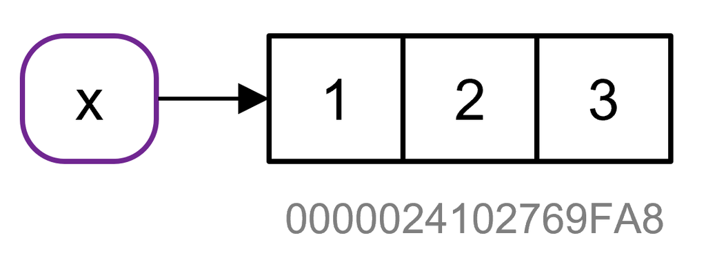

On the scheme above, the name, `x`, is drawn with a rounded rectangle. It has an arrow that points to (or binds) the value, the vector `c(1, 2, 3)`. The arrow points in opposite direction to the assignment arrow: `<-` creates a binding from the name on the left-hand side to the object on the right-hand side.

### Copy-on-Modify

Let’s bind `x` and `y` to the same underlying value and then modify `y`.

```r
# Create an integer vector and name it as x.
x <- c(1, 2, 3)
# Bind the object of x to a new name y.
y <- x
# Modify y by changing the value of the third element to 4.
y[[3]] <- 4
x ; y # See what happens...
```

```
## [1] 1 2 3
```

```
## [1] 1 2 4
```

Modifying `y` clearly didn’t modify `x`. So what happened to the shared binding? While the value associated with `y` changed, the original object did not. Instead, R created a new object with one value changed, then rebound `y` to that object.

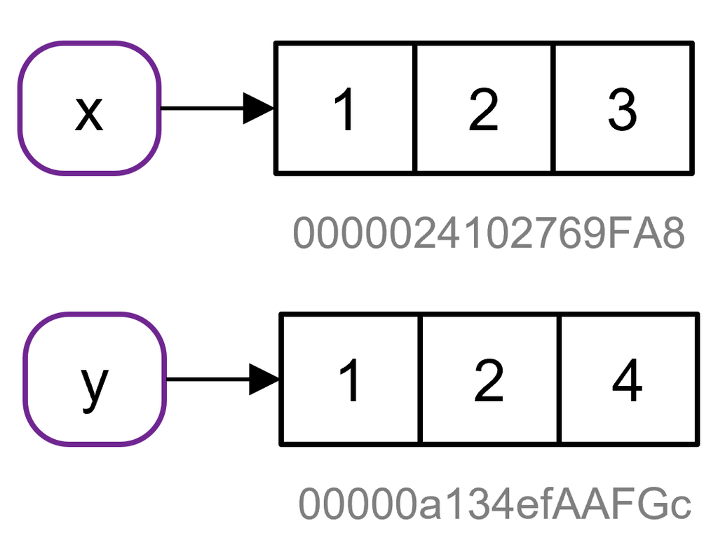

This behavior is called **copy-on-modify**. Understanding it will radically improve your intuition about the performance of R code. A related way to describe this behavior is to say that R objects are *immutable*.

You can see when an object gets copied with the help of `tracemem()` or `lobstr::obj_addr()`. Once you call that function with an object, you’ll get the object’s current address.

```r
# Print memory address of x and y.
lobstr::obj_addr(x) ; lobstr::obj_addr(y)
```

```
## [1] "0x1e4f8d02268"
```

```
## [1] "0x1e4f8d094e8"
```

### Modify-in-Place

As we’ve seen above, modifying an R object usually creates a copy. There are two exceptions, however.

- **Objects with a single binding** get a special performance optimization.
- **Environments**, a special type of object, are always modified in place.

### Footnotes

[^1]: The pipe-forward operator `|>` was introduced in R 4.1 and is syntactic sugar for chained method calls. Or, stated more simply, it lets you pass an intermediate result onto the next function.
[^2]: `%>%` is a pipe-forward implementation from the **magrittr** package. The behaviour of the magrittr pipe `%>%` and the native pipe `|>` is by and large the same.